# Оценка рынка недвижимости Санкт-Петербурга и Ленинградской области

### Средняя стоимость за м2

Производится оценка средней стоимости за м2 для недвижимости в 10-ти самых популярных населенных пунктах.

```python
price_per_square_meter = df.pivot_table(index='locality_name',
                                                 values='sqare_meter_price',
                                                 aggfunc=['mean','count'])
price_per_square_meter.columns = ['sqare_meter_price', 'count']
price_per_square_meter = price_per_square_meter.sort_values(by='count', ascending=False).head(10)
price_per_square_meter = price_per_square_meter.sort_values(by='sqare_meter_price', ascending=True)

price_per_square_meter.style.format("{:,.0f}")
```

| locality_name | sqare_meter_price | count |
| --- | --- | --- |
| Выборг | 58,260 | 225 |
| Всеволожск | 68,650 | 383 |
| Гатчина | 69,079 | 300 |
| Колпино | 75,208 | 334 |
| Шушары | 77,494 | 419 |
| Мурино | 84,660 | 491 |
| Парголово | 89,487 | 290 |
| Кудрово | 94,580 | 420 |
| Пушкин | 102,968 | 355 |
| Санкт-Петербург | 111,946 | 14,871 |

Разумеется, наибольшее количество объявлений размещено в Санкт-Петербурге.  
Также в рейтинг вошли несколько крупных пригородов, а также г.Выборг.

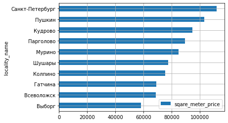

```python
price_per_square_meter.plot(y='sqare_meter_price',
                            kind = 'barh',
                            grid=True);
```

Средняя стоимость квадратного метра жилья в Санкт-Петербурге превышает 100 тыс. рублей,  
в то время как в Выборге она составляет менее 60 тыс.

```python
price_by_city_center = df.query('locality_name == "Санкт-Петербург"')
[['last_price', 'cityCenters_nearest_km']]

price_by_city_center = price_by_city_center.pivot_table(index='cityCenters_nearest_km',
                                                        values='last_price')
price_by_city_center
```

| cityCenters_nearest_km | last_price |
| --- | --- |
| 0 | 1.408126e+07 |
| 1 | 1.217975e+07 |
| 2 | 1.240487e+07 |
| 3 | 1.019058e+07 |
| 4 | 1.108154e+07 |
| 5 | 1.162560e+07 |
| 6 | 1.167418e+07 |
| 7 | 1.228464e+07 |
| 8 | 9.023982e+06 |
| 9 | 6.956927e+06 |
| 10 | 6.431659e+06 |
| 11 | 6.099383e+06 |
| 12 | 5.837334e+06 |
| 13 | 6.103690e+06 |
| 14 | 5.628030e+06 |
| 15 | 5.815100e+06 |
| 16 | 5.375821e+06 |
| 17 | 5.269070e+06 |
| 18 | 5.057149e+06 |
| 19 | 5.167510e+06 |
| 20 | 4.657778e+06 |
| 21 | 5.484809e+06 |
| 22 | 5.382048e+06 |
| 23 | 4.780608e+06 |
| 24 | 3.890687e+06 |
| 25 | 4.335000e+06 |
| 26 | 4.286413e+06 |
| 27 | 8.300000e+06 |
| 28 | 5.026429e+06 |
| 29 | 4.236667e+06 |

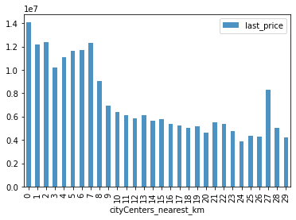

```python
price_by_city_center.plot(kind = 'bar', alpha = 0.8)
```

Заметно изменение цены квартир в зависимости от удаленности от центра города:  
В центре недвижимость стоит порядка 12 млн. рублей  
На окраине цена колеблется около 4 млн. рублей

Для значения удаленности равной 27км наблюдается выброс. Необходимо изучить его причину.

```python
df.query('locality_name == "Санкт-Петербург" and cityCenters_nearest_km == 27').pivot_table(index='locality_name', aggfunc='count')['last_price']
```

```
locality_name
Санкт-Петербург    2
Name: last_price, dtype: int64
```

Аномальное значение объясняется тем, что для этого значения удаленности всего 2 значения цены в Санкт-Петербурге, что не является релевантной выборкой.

## Выводы

**1. Оценка распределения значений**

- Наибольшее число объявлений представлено для одно- и двухкомнатных квартир, стоимостью от 3 до 5 млн. руб. и общей площадью от 30 до 50 м2.
- Высота потолков большинства представленных квартир находится в диапазоне от 2,5 до 2,8м и кратна 5см.
- Больше всего квартир расположено в 5 и 9-этажных домах.
- Объявления о продаже обычно размещаются в будние дни, чаще всего - весной. Также за последние годы количество квартир, продаваемых через сервис Яндекс.Недвижимость выросло в 8 раз.

**2. Зависимость цены от различных параметров**

- Стоимость недвижимости линейно зависит от ее площади и количества комнат.
- Стоимость недвижимости на первом и последнем этажах ниже, чем на промежуточных на 15-20%.
- Наличие поблизости парков, а также удаленность от аэропорта практически не влияют на стоимость жилья. Удаленность от центра, наоборот, играет важную роль в формировании стоимости жилья.
- День недели и месяц, когда было размещено объявление практически не коррелирует со стоимостью недвижимости.

**3. Изучение скорости продажи недвижимости**

- Не стоит расчитывать на срочную продажу квартиры, обычно это занимает порядка 3 месяцев.